# From single-cell RNA counts to robust communities

PBMC 3k · Seurat, scDblFinder and robin

Author

Domenico Sgambato

# 1 What you will learn

This tutorial analyses **single-cell RNA expression** from the PBMC granulocyte-sorted 3k dataset used in the supplied analysis. It uses the gene-expression matrix from the same HDF5 file and follows the single-cell reference vignette’s progression from counts to a cell graph.

The instructor-led analysis compares **Louvain, Leiden, Fast greedy and Walktrap**. The participant exercise holds the algorithm fixed and compares **Leiden resolutions 0.5–1.1**. No winner or numerical result is assumed in advance.

The robustness input is the **unweighted RNA shared nearest-neighbour graph (`RNA_snn`)** constructed from RNA PCs 1–20. All candidates see the same graph and cells. UMAP coordinates are used for display, never as input to robin.

# 2 Before the workshop

## 2.1 Software

Use R with Seurat v5, igraph, Quarto and the CRAN version of robin (2.0.0 API), supporting separate `args1` / `args2`. Installation is a preparation step, not an operation repeated during rendering.

```r
install.packages(c("Seurat", "igraph", "ggplot2", "patchwork",
                   "knitr", "BiocManager", "hdf5r", "robin"))
BiocManager::install(c("SingleCellExperiment", "scDblFinder", "BiocParallel"))
```

The current robin implementation uses an internal perturbation grid and replication scheme; this tutorial does not invent `nrep` or `ncores` arguments. The comparisons below use seven socket workers, including on Windows. Full comparisons, particularly Walktrap, can take substantial time. Instructors should precompute outputs before the session.

## 2.2 Input files and project layout

Place this QMD in the project root:

- `pbmc_granulocyte_sorted_3k_filtered_feature_bc_matrix.h5`

This is the filename used in the supplied analysis. Only its `Gene Expression` matrix is used. The raw HDF5 file is not bundled here. Render from the project root with `quarto render singlecell_robin_tutorial.qmd`.

```r
required <- c("Seurat", "SingleCellExperiment", "scDblFinder",
              "BiocParallel", "igraph", "ggplot2", "patchwork", "robin", "knitr")
missing <- required[!vapply(required, requireNamespace, logical(1), quietly = TRUE)]
if (length(missing)) stop("Install missing packages: ", paste(missing, collapse = ", "))
library(Seurat)
library(ggplot2)
library(patchwork)
set.seed(params$seed)
out <- params$output_dir
dir.create(out, recursive = TRUE, showWarnings = FALSE)
for (d in c("objects", "tables", "figures", "robin")) {
  dir.create(file.path(out, d), showWarnings = FALSE)
}
saveRDS(params, file.path(out, "objects", "run_parameters.rds"))
writeLines(capture.output(sessionInfo()), file.path(out, "session_start.txt"))
robin_description <- utils::packageDescription("robin")
writeLines(capture.output(robin_description), file.path(out, "robin_version.txt"))
needed_api <- c("args1", "args2", "type", "BPPARAM")
if (!all(needed_api %in% names(formals(robin::robinCompare)))) {
  stop("Install robin from CRAN, restart R and render again.")
}
h5_file <- "pbmc_granulocyte_sorted_3k_filtered_feature_bc_matrix.h5"
if (!file.exists(h5_file)) stop("Missing input file: ", h5_file)
qc_log <- data.frame(stage = character(), cells = integer())
record_cells <- function(stage, object) {
  data.frame(stage = stage, cells = ncol(object))
}
```

# 3 Import single-cell RNA counts

The original script reports 36,601 RNA features and 2,711 barcodes before filtering. These are reference dimensions, not hard-coded expectations for every release. Raw counts are kept sparse and remain available in the RNA `counts` layer.

```r
counts <- Read10X_h5(h5_file, use.names = TRUE, unique.features = TRUE)
stopifnot(is.list(counts), "Gene Expression" %in% names(counts))
rna <- counts[["Gene Expression"]]
stopifnot(!anyDuplicated(colnames(rna)), !anyDuplicated(rownames(rna)))
obj <- CreateSeuratObject(rna, assay = "RNA", project = "PBMC_granulocyte_3k",
                          min.cells = 0, min.features = 0)
qc_log <- rbind(qc_log, record_cells("Imported RNA", obj))
knitr::kable(data.frame(modality = "RNA", features = nrow(rna), cells = ncol(rna)))
```

| modality | features | cells |
| --- | --- | --- |
| RNA | 36601 | 2711 |

```r
saveRDS(obj, file.path(out, "objects", "01_imported_rna.rds"))
rm(counts, rna)
```

# 4 Quality control and doublet removal

## 4.1 scDblFinder on raw RNA counts

The input is the unnormalised RNA count matrix. scDblFinder detects artificial-doublet-like expression profiles; Singlet calls do not guarantee that every doublet has been removed, particularly homotypic doublets. This example is one capture. For multiple independent captures, run detection with an appropriate capture identifier in `samples`, rather than treating biological cell types as captures.

```r
DefaultAssay(obj) <- "RNA"
sce <- SingleCellExperiment::SingleCellExperiment(
  assays = list(counts = GetAssayData(obj, assay = "RNA", layer = "counts")))
set.seed(params$seed)
sce <- scDblFinder::scDblFinder(sce, BPPARAM = BiocParallel::SerialParam())
idx <- match(colnames(obj), colnames(sce))
stopifnot(!anyNA(idx))
obj$scDblFinder_class <- sce$scDblFinder.class[idx]
obj$scDblFinder_score <- sce$scDblFinder.score[idx]
write.csv(obj[[]], file.path(out, "tables", "doublet_calls_all_cells.csv"))
knitr::kable(as.data.frame(table(obj$scDblFinder_class)))
```

| Var1 | Freq |
| --- | --- |
| singlet | 2589 |
| doublet | 122 |

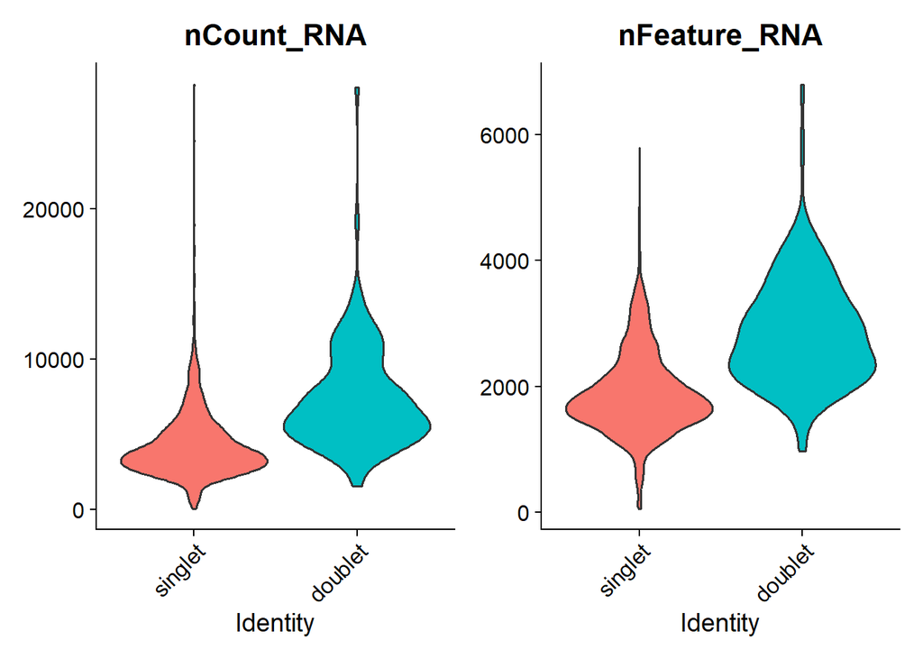

```r
VlnPlot(obj, features = c("nCount_RNA", "nFeature_RNA"),
        group.by = "scDblFinder_class", pt.size = 0)
```

```r
obj <- subset(obj, cells = colnames(obj)[obj$scDblFinder_class == "singlet"])
qc_log <- rbind(qc_log, record_cells("RNA singlets", obj))
```

## 4.2 RNA metrics and filtering

Retain the exact RNA inequalities used in the supplied analysis. These are dataset-specific choices. Inspect pre-filter distributions before applying them; a global threshold can remove valid populations with unusual RNA content.

```r
stopifnot(any(grepl("^MT-", rownames(obj[["RNA"]]))))
obj[["percent.mt"]] <- PercentageFeatureSet(obj, pattern = "^MT-", assay = "RNA")
# Percentili delle metriche RNA: dopo scDblFinder, prima del filtro qualità
qc_metrics <- c("nFeature_RNA", "nCount_RNA", "percent.mt")
probs <- c(0, 0.01, 0.05, 0.25, 0.50, 0.75, 0.95, 0.99, 1)

qc_percentiles <- data.frame(
  Percentile = paste0(probs * 100, "%"),
  sapply(qc_metrics, function(metric) {
    quantile(obj[[]][[metric]], probs = probs, na.rm = TRUE, names = FALSE)
  }),
  check.names = FALSE
)

print(knitr::kable(qc_percentiles, digits = 2))
```

```
|Percentile | nFeature_RNA| nCount_RNA| percent.mt|
|:----------|------------:|----------:|----------:|
|0%         |        59.00|      70.00|       0.00|
|1%         |       488.52|     702.36|       0.61|
|5%         |      1057.00|    1873.00|       2.91|
|25%        |      1484.00|    2876.00|       7.37|
|50%        |      1767.00|    3720.00|       9.83|
|75%        |      2184.00|    5060.00|      12.68|
|95%        |      3148.60|    8257.60|      17.53|
|99%        |      3630.04|   10711.32|      25.95|
|100%       |      5793.00|   28228.00|      82.26|
```

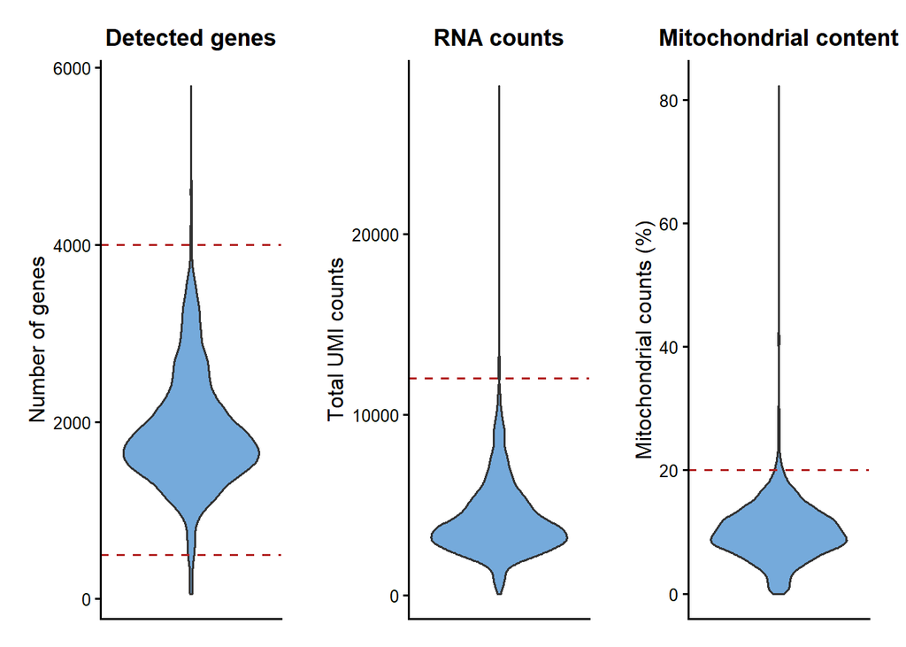

```r
write.csv(obj[[]], file.path(out, "tables", "rna_qc_metrics_before_filter.csv"))

qc_violin <- function(feature, title, y_label, thresholds) {
  VlnPlot(
    obj,
    features = feature,
    pt.size = 0,
    cols = "#75AADB"
  ) +
    NoLegend() +
    geom_hline(
      yintercept = thresholds,
      linetype = "dashed",
      colour = "firebrick",
      linewidth = 0.6
    ) +
    labs(title = title, x = NULL, y = y_label) +
    theme_classic(base_size = 12) +
    theme(
      plot.title = element_text(
        size = 13, face = "bold", hjust = 0.5
      ),
      axis.text.x = element_blank(),
      axis.ticks.x = element_blank(),
      plot.margin = margin(10, 15, 10, 10),
      legend.position = "none"
    )
}

p_genes <- qc_violin(
  "nFeature_RNA", "Detected genes", "Number of genes",
  c(500, 4000)
)

p_counts <- qc_violin(
  "nCount_RNA", "RNA counts", "Total UMI counts",
  12000
)

p_mt <- qc_violin(
  "percent.mt", "Mitochondrial content", "Mitochondrial counts (%)",
  20
)

p_qc <- patchwork::wrap_plots(
  p_genes, p_counts, p_mt,
  ncol = 3
)

print(p_qc)
```

```r
obj <- subset(obj, subset = nFeature_RNA > 500 & nFeature_RNA < 4000 &
                nCount_RNA < 12000 & percent.mt < 20)
qc_log <- rbind(qc_log, record_cells("RNA QC", obj))
```

```r
stopifnot(ncol(obj) > 50)
knitr::kable(qc_log)
```

| stage | cells |
| --- | --- |
| Imported RNA | 2711 |
| RNA singlets | 2589 |
| RNA QC | 2498 |

```r
write.csv(qc_log, file.path(out, "tables", "cell_retention.csv"), row.names = FALSE)
write.csv(obj[[]], file.path(out, "tables", "rna_qc_metrics_retained.csv"))
saveRDS(obj, file.path(out, "objects", "02_rna_qc_filtered.rds"))
```

# 5 RNA normalisation and dimensionality reduction

## 5.1 RNA: log-normalisation, variable genes, PCA and SNN

LogNormalize divides counts by cellular totals, multiplies by 10,000 and applies `log1p`. VST selects 3,000 variable genes; it is not a replacement for normalising the expression matrix. PCA and graph construction use scaled variable genes. The 20-PC choice follows the source; inspect the elbow plot before transferring it to another dataset. `FindNeighbors` uses Seurat defaults for other settings (including `k.param = 20` and `prune.SNN = 1/15`), recorded explicitly below.

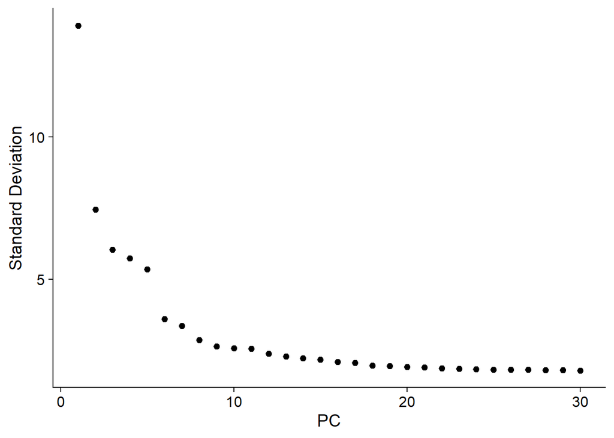

```r
DefaultAssay(obj) <- "RNA"
obj <- NormalizeData(obj, normalization.method = "LogNormalize", scale.factor = 10000)
obj <- FindVariableFeatures(obj, selection.method = "vst", nfeatures = 3000)
obj <- ScaleData(obj, features = VariableFeatures(obj))
obj <- RunPCA(obj, features = VariableFeatures(obj), npcs = 30, seed.use = params$seed)
ElbowPlot(obj, ndims = 30)
```

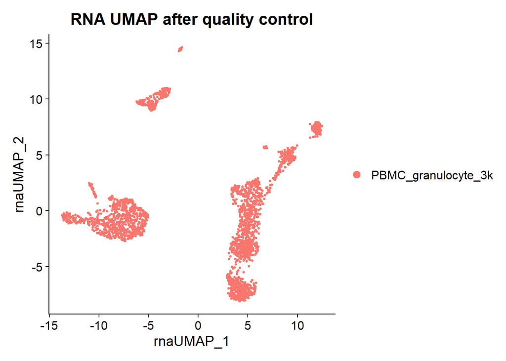

```r
obj <- FindNeighbors(obj, reduction = "pca", dims = 1:20,
                     graph.name = c("RNA_nn", "RNA_snn"), k.param = 20, prune.SNN = 1/15)
obj <- RunUMAP(obj, reduction = "pca", dims = 1:20,
               reduction.name = "umap.rna", reduction.key = "rnaUMAP_", seed.use = params$seed)

DimPlot(
  obj,
  reduction = "umap.rna",
  group.by = "orig.ident"
) +
  ggtitle("RNA UMAP after quality control")
```

# 6 Construct the robustness graph

The RNA SNN graph connects cells according to their shared PCA-space neighbours. The Seurat weights encode neighbour-overlap similarities. Here we binarise the adjacency matrix: each retained SNN connection becomes one unweighted edge. The graph is undirected and self-loops are removed.

```r
adj <- as(obj[["RNA_snn"]], "dgCMatrix")

stopifnot(
  identical(rownames(adj), colnames(adj)),
  Matrix::isSymmetric(adj)
)
# One edge for every positive SNN entry; no edge weights or parallel edges.
adj_binary <- (adj > 0) * 1
g_full <- igraph::graph_from_adjacency_matrix(
  adj_binary, mode = "undirected", weighted = NULL, diag = FALSE
)
stopifnot(igraph::is_simple(g_full), !igraph::is_directed(g_full),
          !igraph::is_weighted(g_full))
cc <- igraph::components(g_full)
g <- g_full
stopifnot(!igraph::is_weighted(g))
graph_audit <- data.frame(source = "RNA_snn",
  full_cells = igraph::vcount(g_full), full_edges = igraph::ecount(g_full),
  components = cc$no, retained_cells = igraph::vcount(g), retained_edges = igraph::ecount(g))
knitr::kable(graph_audit)
```

| source | full_cells | full_edges | components | retained_cells | retained_edges |
| --- | --- | --- | --- | --- | --- |
| RNA_snn | 2498 | 95856 | 2 | 2498 | 95856 |

```r
write.csv(graph_audit, file.path(out, "tables", "graph_audit.csv"), row.names = FALSE)
write.csv(data.frame(barcode = igraph::V(g_full)$name,
                     included = igraph::V(g_full)$name %in% igraph::V(g)$name),
          file.path(out, "tables", "graph_cell_inclusion.csv"), row.names = FALSE)
saveRDS(g, file.path(out, "objects", "03_robin_graph.rds"))
saveRDS(obj, file.path(out, "objects", "03_singlecell_rna.rds"))
```

# 7 Instructor demonstration: which algorithm is most robust?

## 7.1 Fix the objective and algorithm settings

Louvain and Leiden use modularity with resolution 1. Leiden’s objective is explicit: its igraph default can differ. Fast greedy and Walktrap do not offer the same resolution control; the comparison therefore concerns these specified configurations, not an unconditional ranking of algorithm families.

The robin dispatcher uses `leiden_objective_function` for this setting; passing `objective_function` through `args1` can duplicate the underlying igraph argument. The helper also accommodates igraph versions that call the resolution argument `resolution_parameter` rather than `resolution`.

```r
leiden_resolution_key <- if ("resolution" %in% names(formals(igraph::cluster_leiden))) {
  "resolution"
} else "resolution_parameter"
leiden_args <- function(resolution) {
  c(list(leiden_objective_function = "modularity", n_iterations = 10L),
    setNames(list(resolution), leiden_resolution_key))
}
configs <- list(louvain = list(resolution = 1), leiden = leiden_args(1),
                fastGreedy = list(), walktrap = list(steps = 4L))
# The same settings are used for original partitions and every perturbed graph.
# Use the same CRAN clustering function for summaries and perturbations.
partition <- function(graph, method, args) {
  do.call(robin::methodCommunity, c(list(graph = graph, method = method), args))
}
# Cluster the original graph once with each method.
# Resetting the seed before each run preserves the original calculation.
partitions <- list()
for (method in names(configs)) {
  set.seed(params$seed)
  partitions[[method]] <- partition(g, method, configs[[method]])
}

# Summarise the number and sizes of communities.
summary_rows <- list()
for (method in names(partitions)) {
  membership <- igraph::membership(partitions[[method]])
  sizes <- table(membership)
  summary_rows[[length(summary_rows) + 1]] <- data.frame(
    method = method,
    communities = length(unique(membership)),
    smallest = min(sizes),
    largest = max(sizes),
    modularity = igraph::modularity(g, membership)
  )
}
cluster_summary <- do.call(rbind, summary_rows)
knitr::kable(cluster_summary)
```

| method | communities | smallest | largest | modularity |
| --- | --- | --- | --- | --- |
| louvain | 13 | 24 | 422 | 0.8016641 |
| leiden | 13 | 24 | 422 | 0.8024355 |
| fastGreedy | 6 | 29 | 877 | 0.7158021 |
| walktrap | 15 | 19 | 442 | 0.7883824 |

```r
write.csv(cluster_summary, file.path(out, "tables", "algorithm_clusters.csv"), row.names = FALSE)
```

## 7.2 robinCompare: all six pairs

Each curve measures the distance between a method’s partition on the original graph and its partitions after perturbation. It does **not** measure the distance between Louvain and Leiden themselves. We use VI, which robin normalises internally; lower curves indicate greater stability. For the unweighted graph, CRAN robin perturbs topology through degree-preserving swap attempts. No edge weights are perturbed. The horizontal axis is a perturbation control, not a guaranteed fraction of distinct replaced edges.

The inspected CRAN unweighted implementation uses levels 0, 0.05, …, 0.60 and ten replicates at each positive level. It sets the zero-perturbation distance to zero; the origin therefore does not assess optimiser variability. Repeated clustering on an unchanged graph would be a separate diagnostic. Record the robin version, since these implementation details can change.

```r
# Results are filled in by the next chunk.
method_results <- list()
method_auc <- data.frame()

# Each comparison below calls robinCompare directly.
# No custom comparison or AUC function is needed.
```

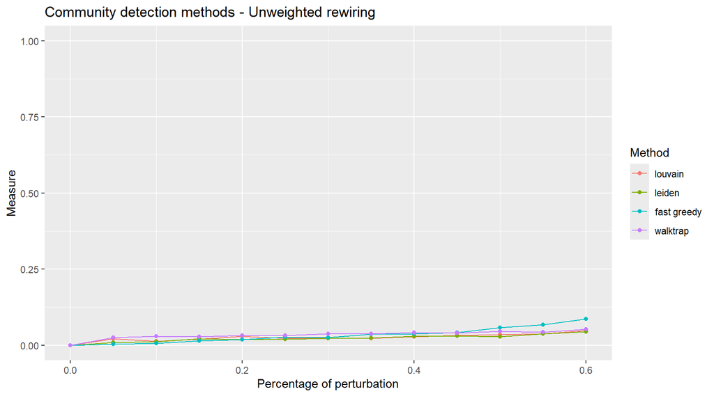

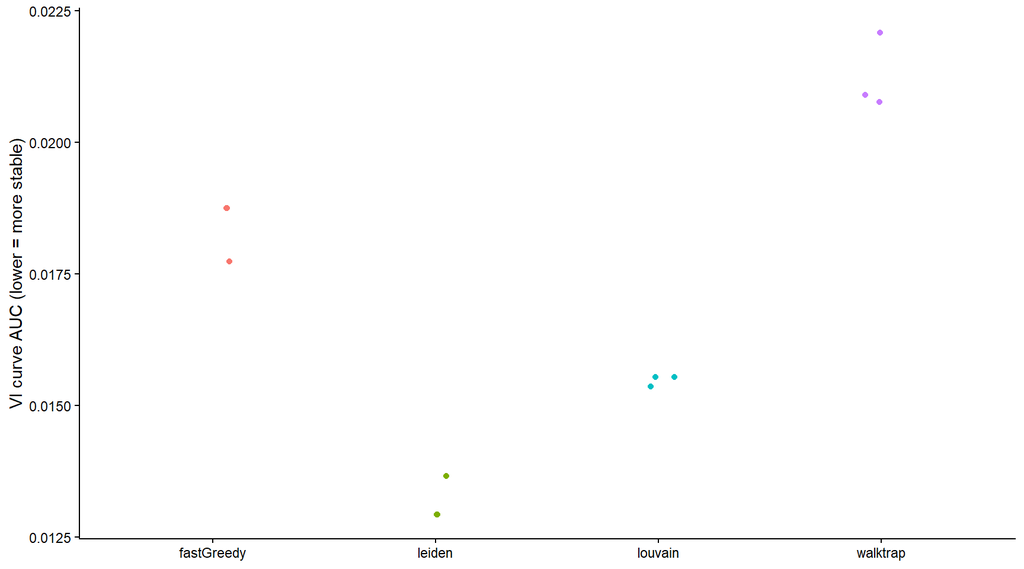

```r
if (isTRUE(params$run_method_comparison)) {
  rows <- vector("list", 6)

  # Comparison 1: louvain versus leiden
  # Run the comparison; hide console text, keep the result.
  set.seed(params$seed)
  invisible(capture.output(
    result <- robin::robinCompare(
      graph = g,
      method1 = "louvain",
      args1 = list(resolution = 1),
      method2 = "leiden",
      args2 = leiden_args(1),
      measure = "vi",
      type = "independent",
      BPPARAM = BiocParallel::SnowParam(
        workers = 7,
        type = "SOCK",
        RNGseed = params$seed
      ),
      verbose = FALSE
    )
  ))
  method_results[["louvain_vs_leiden"]] <- result
  saveRDS(result, file.path(out, "robin", "louvain_vs_leiden.rds"))

  # AUC follows the order method1, method2.
  a <- as.numeric(robin::robinAUC(result))
  stopifnot(length(a) == 2L, all(is.finite(a)))
  rows[[1]] <- data.frame(
    comparison = "louvain_vs_leiden",
    candidate = c("louvain", "leiden"),
    AUC = a
  )

  # Comparison 2: louvain versus fastGreedy
  # Run the comparison; hide console text, keep the result.
  set.seed(params$seed)
  invisible(capture.output(
    result <- robin::robinCompare(
      graph = g,
      method1 = "louvain",
      args1 = list(resolution = 1),
      method2 = "fastGreedy",
      args2 = list(),
      measure = "vi",
      type = "independent",
      BPPARAM = BiocParallel::SnowParam(
        workers = 7,
        type = "SOCK",
        RNGseed = params$seed
      ),
      verbose = FALSE
    )
  ))
  method_results[["louvain_vs_fastGreedy"]] <- result
  saveRDS(result, file.path(out, "robin", "louvain_vs_fastGreedy.rds"))

  # AUC follows the order method1, method2.
  a <- as.numeric(robin::robinAUC(result))
  stopifnot(length(a) == 2L, all(is.finite(a)))
  rows[[2]] <- data.frame(
    comparison = "louvain_vs_fastGreedy",
    candidate = c("louvain", "fastGreedy"),
    AUC = a
  )

  # Comparison 3: louvain versus walktrap
  # Run the comparison; hide console text, keep the result.
  set.seed(params$seed)
  invisible(capture.output(
    result <- robin::robinCompare(
      graph = g,
      method1 = "louvain",
      args1 = list(resolution = 1),
      method2 = "walktrap",
      args2 = list(steps = 4),
      measure = "vi",
      type = "independent",
      BPPARAM = BiocParallel::SnowParam(
        workers = 7,
        type = "SOCK",
        RNGseed = params$seed
      ),
      verbose = FALSE
    )
  ))
  method_results[["louvain_vs_walktrap"]] <- result
  saveRDS(result, file.path(out, "robin", "louvain_vs_walktrap.rds"))

  # AUC follows the order method1, method2.
  a <- as.numeric(robin::robinAUC(result))
  stopifnot(length(a) == 2L, all(is.finite(a)))
  rows[[3]] <- data.frame(
    comparison = "louvain_vs_walktrap",
    candidate = c("louvain", "walktrap"),
    AUC = a
  )

  # Comparison 4: leiden versus fastGreedy
  # Run the comparison; hide console text, keep the result.
  set.seed(params$seed)
  invisible(capture.output(
    result <- robin::robinCompare(
      graph = g,
      method1 = "leiden",
      args1 = leiden_args(1),
      method2 = "fastGreedy",
      args2 = list(),
      measure = "vi",
      type = "independent",
      BPPARAM = BiocParallel::SnowParam(
        workers = 7,
        type = "SOCK",
        RNGseed = params$seed
      ),
      verbose = FALSE
    )
  ))
  method_results[["leiden_vs_fastGreedy"]] <- result
  saveRDS(result, file.path(out, "robin", "leiden_vs_fastGreedy.rds"))

  # AUC follows the order method1, method2.
  a <- as.numeric(robin::robinAUC(result))
  stopifnot(length(a) == 2L, all(is.finite(a)))
  rows[[4]] <- data.frame(
    comparison = "leiden_vs_fastGreedy",
    candidate = c("leiden", "fastGreedy"),
    AUC = a
  )

  # Comparison 5: leiden versus walktrap
  # Run the comparison; hide console text, keep the result.
  set.seed(params$seed)
  invisible(capture.output(
    result <- robin::robinCompare(
      graph = g,
      method1 = "leiden",
      args1 = leiden_args(1),
      method2 = "walktrap",
      args2 = list(steps = 4),
      measure = "vi",
      type = "independent",
      BPPARAM = BiocParallel::SnowParam(
        workers = 7,
        type = "SOCK",
        RNGseed = params$seed
      ),
      verbose = FALSE
    )
  ))
  method_results[["leiden_vs_walktrap"]] <- result
  saveRDS(result, file.path(out, "robin", "leiden_vs_walktrap.rds"))

  # AUC follows the order method1, method2.
  a <- as.numeric(robin::robinAUC(result))
  stopifnot(length(a) == 2L, all(is.finite(a)))
  rows[[5]] <- data.frame(
    comparison = "leiden_vs_walktrap",
    candidate = c("leiden", "walktrap"),
    AUC = a
  )

  # Comparison 6: fastGreedy versus walktrap
  # Run the comparison; hide console text, keep the result.
  set.seed(params$seed)
  invisible(capture.output(
    result <- robin::robinCompare(
      graph = g,
      method1 = "fastGreedy",
      args1 = list(),
      method2 = "walktrap",
      args2 = list(steps = 4),
      measure = "vi",
      type = "independent",
      BPPARAM = BiocParallel::SnowParam(
        workers = 7,
        type = "SOCK",
        RNGseed = params$seed
      ),
      verbose = FALSE
    )
  ))
  method_results[["fastGreedy_vs_walktrap"]] <- result
  saveRDS(result, file.path(out, "robin", "fastGreedy_vs_walktrap.rds"))

  # AUC follows the order method1, method2.
  a <- as.numeric(robin::robinAUC(result))
  stopifnot(length(a) == 2L, all(is.finite(a)))
  rows[[6]] <- data.frame(
    comparison = "fastGreedy_vs_walktrap",
    candidate = c("fastGreedy", "walktrap"),
    AUC = a
  )
  method_labels <- function(x) {
  vapply(x, function(label) {
    if (grepl("fast.?greedy", label, ignore.case = TRUE)) {
      "fast greedy"
    } else if (grepl("louvain", label, ignore.case = TRUE)) {
      "louvain"
    } else if (grepl("leiden", label, ignore.case = TRUE)) {
      "leiden"
    } else if (grepl("walktrap", label, ignore.case = TRUE)) {
      "walktrap"
    } else {
      label
    }
  }, character(1), USE.NAMES = FALSE)
}
  # One curve per algorithm: use the three comparisons sharing Louvain.
  # All six pairwise results remain saved and included in the AUC table.
  p_methods <- robin::plotMultiCompare(
    method_results[["louvain_vs_leiden"]],
    method_results[["louvain_vs_fastGreedy"]],
    method_results[["louvain_vs_walktrap"]],
    title = "Community detection methods - Unweighted rewiring",
    ylim1 = TRUE
  )

  p_methods <- p_methods +
  scale_colour_discrete(name = "Method", labels = method_labels) +
  scale_fill_discrete(name = "Method", labels = method_labels)

print(p_methods)

ggsave(
  file.path(out, "figures", "methods_Rewire_combined.pdf"),
  plot = p_methods,
  width = 12,
  height = 7
)
  method_auc <- do.call(rbind, rows)
  write.csv(method_auc, file.path(out, "tables", "method_auc_all_pairs.csv"), row.names = FALSE)
  knitr::kable(method_auc)
  print(ggplot(method_auc, aes(x = candidate, y = AUC, colour = candidate)) +
          geom_point(position = position_jitter(width = 0.08, height = 0, seed = params$seed)) +
          theme_classic() + guides(colour = "none") +
          labs(x = NULL, y = "VI curve AUC (lower = more stable)"))
}
```

AUC summarises a whole curve over robin’s perturbation interval. Inspect curve crossings before relying on it. Each candidate appears in three pairwise runs; report their variation rather than selecting a favourable occurrence or treating these values as independent biological replicates. Lower VI can also arise from uninformative coarse partitions. Interpret the cluster summary and markers alongside stability. This is a robustness comparison on one dataset and one graph construction.

## 7.3 Optional functional tests

```r
# Run after the comparisons. Inspect the returned test objects before extracting p-values.
functional_tests <- lapply(method_results, robin::robinFDATest)
saveRDS(functional_tests, file.path(out, "robin", "method_functional_tests.rds"))
# If reporting six scalar pairwise p-values, adjust that family (e.g. Holm).
# Functional differences alone neither identify the better direction nor establish biological accuracy.
```

# 8 Participant exercise: Leiden at different resolutions

## 8.1 Student exercise: comparing two Leiden resolutions

We compare Leiden at resolutions **0.6** and **1.1**, keeping the graph, objective function and perturbation strategy unchanged.

Each curve measures the difference between the partition on the original graph and the partitions obtained after perturbation, using the same resolution. A lower VI curve indicates greater stability.

[figure not shown]

```r
# These are the only two resolution values to change in this exercise.
resolution_1 <- 0.6
resolution_2 <- 1.1

# Run the comparison; hide console text, keep the result.
set.seed(123)
invisible(capture.output(
  leiden_comparison <- robin::robinCompare(
    graph = g,
    method1 = "leiden",
    args1 = leiden_args(resolution_1),
    method2 = "leiden",
    args2 = leiden_args(resolution_2),
    measure = "vi",
    type = "independent",
    BPPARAM = BiocParallel::SnowParam(
      workers = 7,
      type = "SOCK",
      RNGseed = 123
    ),
    verbose = FALSE
  )
))

# Set explicit labels: CRAN otherwise calls both curves "leiden".
leiden_comparison$model1 <- paste0("leiden_resolution_", resolution_1)
leiden_comparison$model2 <- paste0("leiden_resolution_", resolution_2)

# Save the comparison
saveRDS(
  leiden_comparison,
  file.path(out, "robin", "leiden_0.6_vs_1.1.rds")
)

# Display the comparison with the labels assigned above.
p_leiden <- plot(leiden_comparison)

print(p_leiden)
```

### 8.1.1 Summarise stability using AUC

A lower AUC indicates lower overall instability across the perturbation range. Inspect the curves as well: they may cross.

```r
auc_values <- robin::robinAUC(leiden_comparison)

auc_table <- data.frame(
  Resolution = c(0.6, 1.1),
  AUC = as.numeric(auc_values)
)

knitr::kable(auc_table, digits = 4, row.names = FALSE)
```

| Resolution | AUC |
| --- | --- |
| 0.6 | 0.0377 |
| 1.1 | 0.0136 |

## 8.2 Question and starting point

**Which Leiden resolution provides a useful, stable partition of this same cell graph?** Keep the graph, objective function, perturbation strategy and VI definition fixed. Change only resolution. The exercise is fully implemented below so participants can run it and modify its settings; it does not assume Leiden won the algorithm demonstration.

Participants may start from the saved graph without repeating preprocessing. In a separate R session, load the same packages and helper definitions from this tutorial, set `params` / `out`, then run this entry point:

```r
g <- readRDS(file.path(out, "objects", "03_robin_graph.rds"))
obj <- readRDS(file.path(out, "objects", "03_singlecell_rna.rds"))
```

## 8.3 Inspect the original partitions

Use the grid 0.5, 0.6, …, 1.1. Resolution values under modularity and CPM are not interchangeable. This exercise uses modularity throughout; a numerical resolution does not necessarily reproduce Seurat’s Leiden implementation exactly.

```r
resolutions <- round(seq(0.5, 1.1, by = 0.1), 1)

# Apply Leiden separately at each resolution, always resetting the seed.
resolution_partitions <- list()
for (resolution in resolutions) {
  set.seed(params$seed)
  name <- sprintf("%.1f", resolution)
  resolution_partitions[[name]] <- partition(g, "leiden", leiden_args(resolution))
}

# Build one summary row per resolution.
summary_rows <- list()
for (i in seq_along(resolutions)) {
  membership <- igraph::membership(resolution_partitions[[i]])
  sizes <- table(membership)
  summary_rows[[i]] <- data.frame(
    resolution = resolutions[i],
    communities = length(unique(membership)),
    smallest = min(sizes),
    largest = max(sizes)
  )
}
resolution_summary <- do.call(rbind, summary_rows)
knitr::kable(resolution_summary)
```

| resolution | communities | smallest | largest |
| --- | --- | --- | --- |
| 0.5 | 10 | 29 | 718 |
| 0.6 | 11 | 24 | 693 |
| 0.7 | 11 | 24 | 614 |
| 0.8 | 11 | 25 | 613 |
| 0.9 | 12 | 25 | 612 |
| 1.0 | 13 | 24 | 422 |
| 1.1 | 13 | 24 | 422 |

```r
write.csv(resolution_summary, file.path(out, "tables", "leiden_resolution_clusters.csv"), row.names = FALSE)
```

## 8.4 Compare each resolution with a common reference

The reference is 0.5. Each call compares **Leiden against Leiden**, supplying different argument lists. A common reference gives six interpretable robin plots. The reference curve is estimated anew in each run and may vary; do not silently substitute a different reference AUC from each plot into a single ranking. The table retains every occurrence.

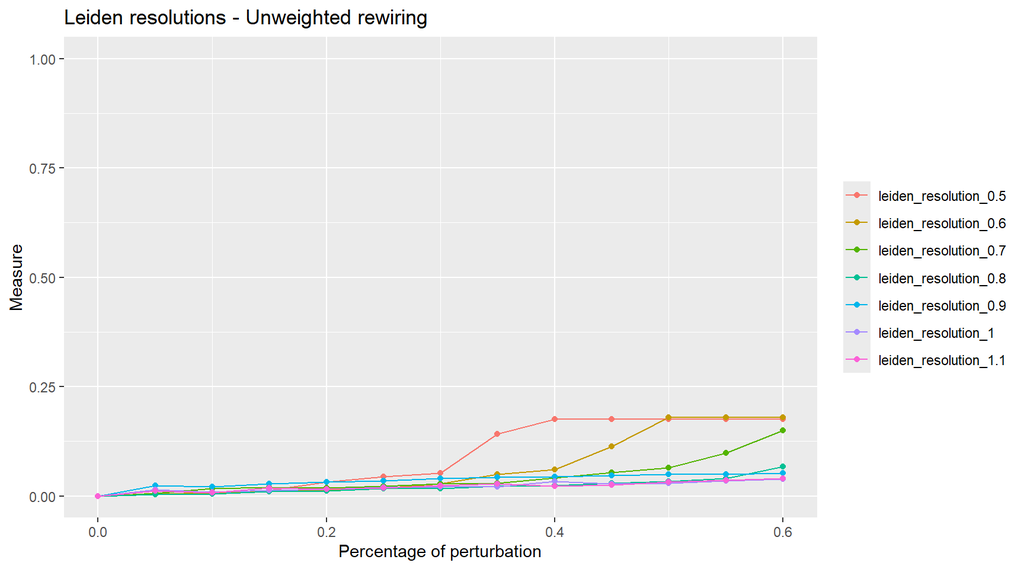

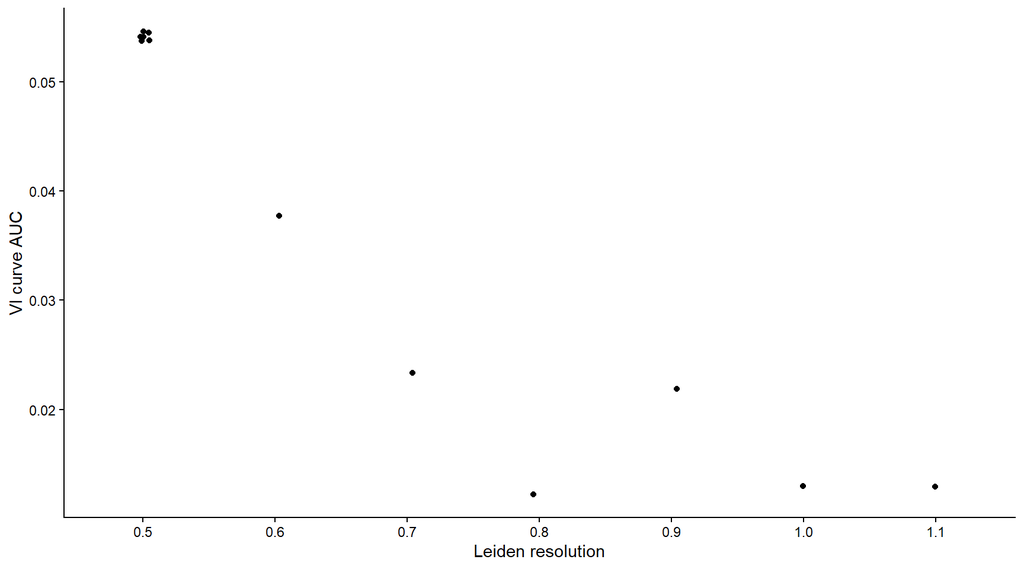

```r
resolution_results <- list()
if (isTRUE(params$run_resolution_exercise)) {
  rows <- vector("list", 6)

  # Comparison 1: Leiden 0.5 versus 0.6
  # Run the comparison; hide console text, keep the result.
  set.seed(params$seed)
  invisible(capture.output(
    result <- robin::robinCompare(
      graph = g,
      method1 = "leiden",
      args1 = leiden_args(0.5),
      method2 = "leiden",
      args2 = leiden_args(0.6),
      measure = "vi",
      type = "independent",
      BPPARAM = BiocParallel::SnowParam(
        workers = 7,
        type = "SOCK",
        RNGseed = params$seed
      ),
      verbose = FALSE
    )
  ))
  # CRAN stores plot labels in model1 and model2.
  result$model1 <- "leiden_resolution_0.5"
  result$model2 <- "leiden_resolution_0.6"
  resolution_results[["leiden_0.5_vs_0.6"]] <- result
  saveRDS(result, file.path(out, "robin", "leiden_0.5_vs_0.6.rds"))

  a <- as.numeric(robin::robinAUC(result))
  stopifnot(length(a) == 2L, all(is.finite(a)))
  rows[[1]] <- data.frame(
    comparison = "leiden_0.5_vs_0.6",
    candidate = c("0.5", "0.6"),
    AUC = a
  )

  # Comparison 2: Leiden 0.5 versus 0.7
  # Run the comparison; hide console text, keep the result.
  set.seed(params$seed)
  invisible(capture.output(
    result <- robin::robinCompare(
      graph = g,
      method1 = "leiden",
      args1 = leiden_args(0.5),
      method2 = "leiden",
      args2 = leiden_args(0.7),
      measure = "vi",
      type = "independent",
      BPPARAM = BiocParallel::SnowParam(
        workers = 7,
        type = "SOCK",
        RNGseed = params$seed
      ),
      verbose = FALSE
    )
  ))
  # CRAN stores plot labels in model1 and model2.
  result$model1 <- "leiden_resolution_0.5"
  result$model2 <- "leiden_resolution_0.7"
  resolution_results[["leiden_0.5_vs_0.7"]] <- result
  saveRDS(result, file.path(out, "robin", "leiden_0.5_vs_0.7.rds"))

  a <- as.numeric(robin::robinAUC(result))
  stopifnot(length(a) == 2L, all(is.finite(a)))
  rows[[2]] <- data.frame(
    comparison = "leiden_0.5_vs_0.7",
    candidate = c("0.5", "0.7"),
    AUC = a
  )

  # Comparison 3: Leiden 0.5 versus 0.8
  # Run the comparison; hide console text, keep the result.
  set.seed(params$seed)
  invisible(capture.output(
    result <- robin::robinCompare(
      graph = g,
      method1 = "leiden",
      args1 = leiden_args(0.5),
      method2 = "leiden",
      args2 = leiden_args(0.8),
      measure = "vi",
      type = "independent",
      BPPARAM = BiocParallel::SnowParam(
        workers = 7,
        type = "SOCK",
        RNGseed = params$seed
      ),
      verbose = FALSE
    )
  ))
  # CRAN stores plot labels in model1 and model2.
  result$model1 <- "leiden_resolution_0.5"
  result$model2 <- "leiden_resolution_0.8"
  resolution_results[["leiden_0.5_vs_0.8"]] <- result
  saveRDS(result, file.path(out, "robin", "leiden_0.5_vs_0.8.rds"))

  a <- as.numeric(robin::robinAUC(result))
  stopifnot(length(a) == 2L, all(is.finite(a)))
  rows[[3]] <- data.frame(
    comparison = "leiden_0.5_vs_0.8",
    candidate = c("0.5", "0.8"),
    AUC = a
  )

  # Comparison 4: Leiden 0.5 versus 0.9
  # Run the comparison; hide console text, keep the result.
  set.seed(params$seed)
  invisible(capture.output(
    result <- robin::robinCompare(
      graph = g,
      method1 = "leiden",
      args1 = leiden_args(0.5),
      method2 = "leiden",
      args2 = leiden_args(0.9),
      measure = "vi",
      type = "independent",
      BPPARAM = BiocParallel::SnowParam(
        workers = 7,
        type = "SOCK",
        RNGseed = params$seed
      ),
      verbose = FALSE
    )
  ))
  # CRAN stores plot labels in model1 and model2.
  result$model1 <- "leiden_resolution_0.5"
  result$model2 <- "leiden_resolution_0.9"
  resolution_results[["leiden_0.5_vs_0.9"]] <- result
  saveRDS(result, file.path(out, "robin", "leiden_0.5_vs_0.9.rds"))

  a <- as.numeric(robin::robinAUC(result))
  stopifnot(length(a) == 2L, all(is.finite(a)))
  rows[[4]] <- data.frame(
    comparison = "leiden_0.5_vs_0.9",
    candidate = c("0.5", "0.9"),
    AUC = a
  )

  # Comparison 5: Leiden 0.5 versus 1.0
  # Run the comparison; hide console text, keep the result.
  set.seed(params$seed)
  invisible(capture.output(
    result <- robin::robinCompare(
      graph = g,
      method1 = "leiden",
      args1 = leiden_args(0.5),
      method2 = "leiden",
      args2 = leiden_args(1.0),
      measure = "vi",
      type = "independent",
      BPPARAM = BiocParallel::SnowParam(
        workers = 7,
        type = "SOCK",
        RNGseed = params$seed
      ),
      verbose = FALSE
    )
  ))
  # CRAN stores plot labels in model1 and model2.
  result$model1 <- "leiden_resolution_0.5"
  result$model2 <- "leiden_resolution_1.0"
  resolution_results[["leiden_0.5_vs_1.0"]] <- result
  saveRDS(result, file.path(out, "robin", "leiden_0.5_vs_1.0.rds"))

  a <- as.numeric(robin::robinAUC(result))
  stopifnot(length(a) == 2L, all(is.finite(a)))
  rows[[5]] <- data.frame(
    comparison = "leiden_0.5_vs_1.0",
    candidate = c("0.5", "1.0"),
    AUC = a
  )

  # Comparison 6: Leiden 0.5 versus 1.1
  # Run the comparison; hide console text, keep the result.
  set.seed(params$seed)
  invisible(capture.output(
    result <- robin::robinCompare(
      graph = g,
      method1 = "leiden",
      args1 = leiden_args(0.5),
      method2 = "leiden",
      args2 = leiden_args(1.1),
      measure = "vi",
      type = "independent",
      BPPARAM = BiocParallel::SnowParam(
        workers = 7,
        type = "SOCK",
        RNGseed = params$seed
      ),
      verbose = FALSE
    )
  ))
  # CRAN stores plot labels in model1 and model2.
  result$model1 <- "leiden_resolution_0.5"
  result$model2 <- "leiden_resolution_1.1"
  resolution_results[["leiden_0.5_vs_1.1"]] <- result
  saveRDS(result, file.path(out, "robin", "leiden_0.5_vs_1.1.rds"))

  a <- as.numeric(robin::robinAUC(result))
  stopifnot(length(a) == 2L, all(is.finite(a)))
  rows[[6]] <- data.frame(
    comparison = "leiden_0.5_vs_1.1",
    candidate = c("0.5", "1.1"),
    AUC = a
  )
  # Display every resolution comparison in one graph.
  p_resolutions <- robin::plotMultiCompare(
    resolution_results[["leiden_0.5_vs_0.6"]],
    resolution_results[["leiden_0.5_vs_0.7"]],
    resolution_results[["leiden_0.5_vs_0.8"]],
    resolution_results[["leiden_0.5_vs_0.9"]],
    resolution_results[["leiden_0.5_vs_1.0"]],
    resolution_results[["leiden_0.5_vs_1.1"]],
    title = "Leiden resolutions - Unweighted rewiring",
    ylim1 = TRUE
  )

resolution_labels <- function(x) {
  sub(
    "^.*resolution(?:_parameter)?_([0-9.]+).*$",
    "leiden_resolution_\\1",
    x,
    perl = TRUE
  )
}

p_resolutions <- p_resolutions +
  scale_colour_discrete(name = NULL, labels = resolution_labels) +
  scale_fill_discrete(name = NULL, labels = resolution_labels)

print(p_resolutions)

ggsave(
  file.path(out, "figures", "leiden_resolutions_Rewire_combined.pdf"),
  plot = p_resolutions,
  width = 12,
  height = 7
)
  resolution_auc <- do.call(rbind, rows)
  write.csv(resolution_auc, file.path(out, "tables", "resolution_auc_all_runs.csv"), row.names = FALSE)
  knitr::kable(resolution_auc)
  print(ggplot(resolution_auc, aes(x = candidate, y = AUC)) +
          geom_point(position = position_jitter(width = 0.05, height = 0, seed = params$seed)) +
          theme_classic() + labs(x = "Leiden resolution", y = "VI curve AUC"))
}
```

## 8.5 Visualise partitions on a fixed UMAP

Cells excluded from the graph component receive `NA` labels. This explicitly distinguishes them from the robustness population. The same RNA embedding is used for every resolution; a change in UMAP layout must not be mistaken for a change in community stability.

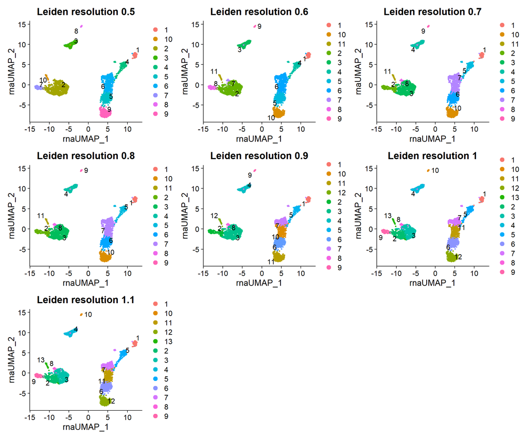

```r
umap_plots <- vector("list", length(resolutions))
for (i in seq_along(resolutions)) {
  field <- paste0("leiden_r", gsub("\\.", "_", sprintf("%.1f", resolutions[i])))
  labels <- setNames(rep(NA_character_, ncol(obj)), colnames(obj))
  z <- igraph::membership(resolution_partitions[[i]])
  labels[igraph::V(g)$name] <- as.character(z)
  obj[[field]] <- labels[colnames(obj)]
  umap_plots[[i]] <- DimPlot(obj, reduction = "umap.rna", group.by = field,
                              label = TRUE, repel = TRUE) +
    ggtitle(paste("Leiden resolution", resolutions[i]))
}
patchwork::wrap_plots(umap_plots, ncol = 3)
```

```r
saveRDS(obj, file.path(out, "objects", "04_singlecell_resolution_labels.rds"))
```

## 8.6 Biological interpretation with RNA markers

This optional step uses resolution 1 only as an example, not an automatically selected optimum. Marker testing here is exploratory: cluster-derived groups are not independent biological replicates. Retain the RNA normalised assay for expression interpretation.

```r
if (isTRUE(params$run_markers)) {
  marker_obj <- subset(obj, cells = igraph::V(g)$name)
  DefaultAssay(marker_obj) <- "RNA"
  Idents(marker_obj) <- "leiden_r1_0"
  markers <- FindAllMarkers(marker_obj, assay = "RNA", only.pos = TRUE,
                             min.pct = 0.25, logfc.threshold = 0.25)
  write.csv(markers, file.path(out, "tables", "rna_markers_leiden_r1.csv"), row.names = FALSE)
  panel <- intersect(c("CD3D", "MS4A1", "NKG7", "LYZ", "FCGR3A", "PPBP"),
                      rownames(marker_obj[["RNA"]]))
  if (length(panel)) print(DotPlot(marker_obj, features = panel) + RotatedAxis())
}
```

## 8.7 Tasks to discuss

1. Which configuration has the lowest curve in the low-perturbation region? Do curves cross?
2. Does the AUC agree with the visual comparison? Is the reference stable across runs?
3. Does the most stable resolution collapse distinct marker-supported populations?
4. What happens when you compare neighbouring resolutions, such as 0.9 versus 1.0?
5. Rebuild `RNA_snn` using a different PCA dimension range or `k.param`, then repeat the analysis. Which changes reflect graph construction rather than the clustering algorithm?

```r
# Optional: compare two neighbouring resolutions.
# Run the comparison; hide console text, keep the result.
set.seed(params$seed)
invisible(capture.output(
  adjacent <- robin::robinCompare(
    graph = g,
    method1 = "leiden",
    args1 = leiden_args(0.9),
    method2 = "leiden",
    args2 = leiden_args(1.0),
    measure = "vi",
    type = "independent",
    BPPARAM = BiocParallel::SnowParam(
      workers = 7,
      type = "SOCK",
      RNGseed = params$seed
    ),
    verbose = FALSE
  )
))
adjacent$model1 <- "leiden_resolution_0.9"
adjacent$model2 <- "leiden_resolution_1.0"
plot(adjacent)
robin::robinAUC(adjacent)
```

Write a short conclusion stating the graph, objective, resolution, perturbation model, AUC/curve evidence, cluster sizes and marker evidence. If stability and biological granularity disagree, describe the tradeoff rather than declaring a universal winner.

# 9 Outputs and reproducibility

`objects/` contains imported, QC-filtered and processed RNA Seurat objects, the exact RNA SNN graph and labelled output. `tables/` contains retention, barcode inclusion, QC, cluster summaries and all AUC occurrences. `robin/` stores comparison objects; `figures/` stores the robin plots as PDF.

The analysis uses seven socket workers for robin and explicitly sets random seeds, but numerical equality across package versions or operating systems is not guaranteed. Save a lockfile and the tested robin commit for workshop distribution. Disabling a comparison parameter skips its heavy computations; it does not load prior results automatically.